```python
import pandas as pd
import matplotlib.pyplot as plt
import numpy as np
%matplotlib inline
```

# Homework 1

## INFO 4871 / 5871

The purpose of this assignment is gain experience working with user profile data as commonly found in recommender systems.

### Hints

The following functions of the Pandas API are worth refreshing your memory on:

- `read_csv`
- `DataFrame.groupby`
- `DataFrame.query`
- `DataFrame.join`
- `DataFrame.crosstab`

Also, the sections of the Pandas documentation on "Indexing and Selecting Data" and "Group By: split-apply-combine".

### More hints

The third-ranked item produced by each recommender should be:

- `PopFreq`: *Forrest Gump*
- `PopFreq` (Filtered): *Lord of the Rings: Fellowship of the Ring*
- `PopRating`: *Touch of Evil*
- `PopRating` (Filtered): *Fight Club*

## Step 1

Load the MovieLens data. There are three files: ratings.csv, movies.csv, tags.csv. Note: the files use "Latin 1" encoding. You'll need to include this information in the call to `read_csv`. Use the `head()` function to show the contents of each data frame after you read it. Hint: Your life will be easier later if you use `movies.set_index('movieId')` to set the index of the `movies` data frame to be the movie id.

```python
ratings = pd.read_csv('ratings.csv', encoding='latin-1')
ratings.head()
```

|  | userId | movieId | rating | timestamp |
| --- | --- | --- | --- | --- |
| 0 | 12882 | 1 | 4.0 | 1147195252 |
| 1 | 12882 | 32 | 3.5 | 1147195307 |
| 2 | 12882 | 47 | 5.0 | 1147195343 |
| 3 | 12882 | 50 | 5.0 | 1147185499 |
| 4 | 12882 | 110 | 4.5 | 1147195239 |

```python
movies = pd.read_csv('movies.csv', encoding='latin-1')
movies = movies.set_index('movieId')
movies.head()
```

| movieId | title | genres |
| --- | --- | --- |
| 1 | Toy Story (1995) | Adventure\|Animation\|Children\|Comedy\|Fantasy |
| 2 | Jumanji (1995) | Adventure\|Children\|Fantasy |
| 3 | Grumpier Old Men (1995) | Comedy\|Romance |
| 4 | Waiting to Exhale (1995) | Comedy\|Drama\|Romance |
| 5 | Father of the Bride Part II (1995) | Comedy |

```python
tags = pd.read_csv('tags.csv', encoding='latin-1')
tags.head()
```

|  | movieId | userId | tag | timestamp |
| --- | --- | --- | --- | --- |
| 0 | 3916 | 12882 | sports | 1147195545 |
| 1 | 4085 | 12882 | Eddie Murphy | 1147195966 |
| 2 | 33660 | 12882 | boxing | 1147195514 |
| 3 | 1197 | 320 | must show | 1145964801 |
| 4 | 1396 | 320 | must show | 1145964810 |

## Step 2

- Compute a rating count data frame: for each movie, how many times has it been rated? (Value of the rating doesn't count)
- Compute the minimum value. Identify the name of a movie that has this minimum count? INFO 5871: (optional for INFO 4871: No hard-coded values.)
- Compute the maximum value. Identify the name of a movie that has the maximum count? INFO 5871: (optional for INFO 4871: No hard-coded values.)
- Plot the rating count distribution as a histogram.

### Create the rating count data frame

```python
movies_only = ratings.drop(['userId', 'rating', 'timestamp'], axis=1)
movies_grouped = movies_only.groupby('movieId')
movie_counts = pd.DataFrame({'count':movies_grouped.size()})
movie_counts.head()
```

| movieId | count |
| --- | --- |
| 1 | 496 |
| 2 | 279 |
| 3 | 78 |
| 4 | 13 |
| 5 | 76 |

### Minimum rated movie

Hard-coded method

```python
count_min = movie_counts['count'].min()
movie_counts['count'].idxmin()
```

```
340
```

```python
min_movie = movies.query('movieId == 340')
print ("The movie rated 3 times is", min_movie['title'].iat[0])
```

```
The movie rated 3 times is War, The (1994)
```

Non-hard-coded method

```python
count_min = movie_counts['count'].min()
min_movieid = movie_counts['count'].idxmin()
min_movie = movies.loc[min_movieid]
print ("The movie rated", count_min, "times is", min_movie['title'])
```

```
The movie rated 3 times is War, The (1994)
```

Alternative using inner join

```python
min_row = movie_counts[movie_counts['count']==count_min]
min_movie = movies.join(min_row, how='inner')
print ("The movie rated", count_min, "times is", min_movie['title'].iat[0])
```

```
The movie rated 3 times is War, The (1994)
```

### Most-rated movie

Hard-coded method

```python
max_movieid = movie_counts['count'].idxmax()
max_movieid
```

```
2571
```

```python
count_max = movie_counts['count'].max()
max_movie = movies.query('movieId == 2571')
print ("The movie rated", count_max, "times is", max_movie['title'].iat[0])
```

```
The movie rated 668 times is Matrix, The (1999)
```

Non-hard-coded method (join)

```python
max_count = movie_counts[movie_counts['count'] == count_max]
max_movie = movies.join(max_count, how='inner')
print ("The movie rated", count_max, "times is", max_movie['title'].iat[0])
```

```
The movie rated 668 times is Matrix, The (1999)
```

Histogram. (Use bins of size 50.)

```
array([[<matplotlib.axes._subplots.AxesSubplot object at 0x113380908>]],
      dtype=object)
```

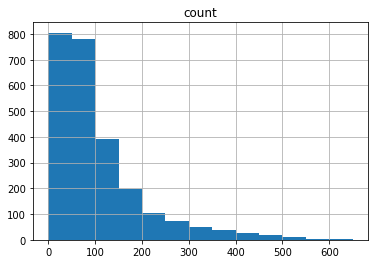

```python
movie_counts.hist(bins=np.arange(0,700, 50))
```

## Step 3

- Compute the rating value distribution: for each possible rating value (0.5, 1,1.5,2.0,2.5, ..., 4.5, 5.0), how many movies have that rating?
- Plot the rating value distribution as a line plot

```python
ratings_only = ratings.drop(['userId', 'movieId', 'timestamp'], axis=1)
ratings_grouped = ratings_only.groupby('rating')
rating_counts = pd.DataFrame({'count':ratings_grouped.size()})
rating_counts
```

| rating | count |
| --- | --- |
| 0.5 | 3595 |
| 1.0 | 5543 |
| 1.5 | 5716 |
| 2.0 | 15978 |
| 2.5 | 19017 |
| 3.0 | 44574 |
| 3.5 | 47305 |
| 4.0 | 66481 |
| 4.5 | 30529 |
| 5.0 | 25767 |

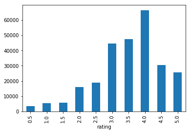

```python
rating_counts.plot(kind="bar", legend=False)
```

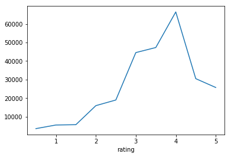

```python
rating_counts.plot(kind="line", legend=False)
```

### *Question:* What does this distribution tell you about the kind of preferences represented in the MovieLens data set?

*Answer:* (max 100 words) The plot shows that most of the ratings are positive ones. People tend to rate movies that they like.

## Step 4

### Create the profile length data frame

```python
users_only = ratings[['userId']]
users_grouped = users_only.groupby('userId')
user_counts = pd.DataFrame({'count':users_grouped.size()})
user_counts.head()
```

| userId | count |
| --- | --- |
| 316 | 129 |
| 320 | 62 |
| 359 | 833 |
| 370 | 411 |
| 910 | 677 |

Hard-coded

```python
min_profile = user_counts['count'].min()
min_profile
```

```
14
```

```python
min_profile_user = user_counts[user_counts['count']==14]
print ("The user with only", min_profile, "ratings is", min_profile_user.index[0])
```

```
The user with only 14 ratings is 138176
```

Non-hard-coded

```python
min_profile_user = user_counts['count'].idxmin()
print ("The user with only", min_profile, "ratings is", min_profile_user)
```

```
The user with only 14 ratings is 138176
```

## Step 5

Build a non-personalized popularity-based top 20 recommender. Ignore the value of the rating and just count how many times a movie appears in someone's ratings. We will call this `PopFreq`.

Can re-use some of the results from above. Sort in descending order

```python
recs = movie_counts.sort_values(by='count', ascending=False)[0:20]
```

```python
recs
```

| movieId | count |
| --- | --- |
| 2571 | 668 |
| 4993 | 628 |
| 356 | 621 |
| 296 | 613 |
| 5952 | 597 |
| 2959 | 588 |
| 7153 | 577 |
| 318 | 564 |
| 260 | 535 |
| 593 | 533 |
| 480 | 524 |
| 6539 | 519 |
| 4306 | 517 |
| 2858 | 516 |
| 1270 | 513 |
| 1196 | 510 |
| 1198 | 505 |
| 2762 | 504 |
| 1 | 496 |
| 4226 | 483 |

Join against the movie table to see what movies these are.

```python
recs.join(movies[['title']])
```

| movieId | count | title |
| --- | --- | --- |
| 2571 | 668 | Matrix, The (1999) |
| 4993 | 628 | Lord of the Rings: The Fellowship of the Ring,... |
| 356 | 621 | Forrest Gump (1994) |
| 296 | 613 | Pulp Fiction (1994) |
| 5952 | 597 | Lord of the Rings: The Two Towers, The (2002) |
| 2959 | 588 | Fight Club (1999) |
| 7153 | 577 | Lord of the Rings: The Return of the King, The... |
| 318 | 564 | Shawshank Redemption, The (1994) |
| 260 | 535 | Star Wars: Episode IV - A New Hope (1977) |
| 593 | 533 | Silence of the Lambs, The (1991) |
| 480 | 524 | Jurassic Park (1993) |
| 6539 | 519 | Pirates of the Caribbean: The Curse of the Bla... |
| 4306 | 517 | Shrek (2001) |
| 2858 | 516 | American Beauty (1999) |
| 1270 | 513 | Back to the Future (1985) |
| 1196 | 510 | Star Wars: Episode V - The Empire Strikes Back... |
| 1198 | 505 | Raiders of the Lost Ark (Indiana Jones and the... |
| 2762 | 504 | Sixth Sense, The (1999) |
| 1 | 496 | Toy Story (1995) |
| 4226 | 483 | Memento (2000) |

## Step 5.5 (INFO 5871 only)

Build a filtered version of `PopFreq` in which ratings below 4 are filtered out. Hint: the `DataFrame.query` function is handy for this.

```python
filtered_ratings = ratings.query('rating >= 4.0')
filtered_movies_grouped = filtered_ratings.groupby('movieId')
filtered_movie_counts = pd.DataFrame({'count':filtered_movies_grouped.size()})
filtered_movie_counts.head()

filtered_recs = filtered_movie_counts.sort_values(by='count', ascending=False)[0:20]
filtered_recs.join(movies[['title']])
```

| movieId | count | title |
| --- | --- | --- |
| 2571 | 522 | Matrix, The (1999) |
| 296 | 491 | Pulp Fiction (1994) |
| 4993 | 483 | Lord of the Rings: The Fellowship of the Ring,... |
| 318 | 477 | Shawshank Redemption, The (1994) |
| 2959 | 470 | Fight Club (1999) |
| 5952 | 432 | Lord of the Rings: The Two Towers, The (2002) |
| 7153 | 426 | Lord of the Rings: The Return of the King, The... |
| 356 | 412 | Forrest Gump (1994) |
| 260 | 397 | Star Wars: Episode IV - A New Hope (1977) |
| 1196 | 393 | Star Wars: Episode V - The Empire Strikes Back... |
| 593 | 388 | Silence of the Lambs, The (1991) |
| 2858 | 383 | American Beauty (1999) |
| 858 | 374 | Godfather, The (1972) |
| 4226 | 373 | Memento (2000) |
| 1198 | 366 | Raiders of the Lost Ark (Indiana Jones and the... |
| 50 | 361 | Usual Suspects, The (1995) |
| 1270 | 356 | Back to the Future (1985) |
| 7361 | 351 | Eternal Sunshine of the Spotless Mind (2004) |
| 4973 | 344 | Amelie (Fabuleux destin d'AmÃ©lie Poulain, Le)... |
| 58559 | 342 | Dark Knight, The (2008) |

Compute the overlap between these recommendations

```python
diff = set(recs[0:10].index) - set(filtered_recs[0:10].index).intersection(recs[0:10].index)
movies['title'].loc[diff]
```

```
movieId
593    Silence of the Lambs, The (1991)
Name: title, dtype: object
```

### *Question:* What movie no longer appears in the top 10 after filtering by rating value? What must be true of this movie for this to be the case?

*Answer*: Silence of the Lambs. A significant number of people must have seen it and rated it but not liked it that much.

## Step 6

Build non-personalized recommender that orders the movies by average rating. We will call this version `PopRating`.

```python
ratings_only = ratings[['movieId', 'rating']]
movie_grouped = ratings_only.groupby('movieId')
```

```python
movie_means = movie_grouped.agg(np.mean)
movie_mean_recs = movie_means.sort_values(by='rating', ascending=False)[0:20]
movie_mean_recs.head()
```

| movieId | rating |
| --- | --- |
| 318 | 4.364362 |
| 858 | 4.315848 |
| 1248 | 4.259259 |
| 2959 | 4.258503 |
| 7502 | 4.247423 |

```python
movie_mean_recs.join(movies[['title']])
```

| movieId | rating | title |
| --- | --- | --- |
| 318 | 4.364362 | Shawshank Redemption, The (1994) |
| 858 | 4.315848 | Godfather, The (1972) |
| 1248 | 4.259259 | Touch of Evil (1958) |
| 2959 | 4.258503 | Fight Club (1999) |
| 7502 | 4.247423 | Band of Brothers (2001) |
| 1203 | 4.246032 | 12 Angry Men (1957) |
| 2859 | 4.220000 | Stop Making Sense (1984) |
| 1221 | 4.218462 | Godfather: Part II, The (1974) |
| 296 | 4.217781 | Pulp Fiction (1994) |
| 2571 | 4.195359 | Matrix, The (1999) |
| 4226 | 4.194617 | Memento (2000) |
| 2019 | 4.191860 | Seven Samurai (Shichinin no samurai) (1954) |
| 4973 | 4.190092 | Amelie (Fabuleux destin d'AmÃ©lie Poulain, Le)... |
| 1939 | 4.189655 | Best Years of Our Lives, The (1946) |
| 926 | 4.189655 | All About Eve (1950) |
| 50 | 4.180617 | Usual Suspects, The (1995) |
| 6016 | 4.170251 | City of God (Cidade de Deus) (2002) |
| 92259 | 4.169231 | Intouchables (2011) |
| 26614 | 4.166667 | Bourne Identity, The (1988) |
| 904 | 4.163900 | Rear Window (1954) |

### *Question:* This list is quite different from the `PopFreq` list. What must be true of "The Godfather" for it to appear on this list, but not the other one?

*Answer:* People who saw it liked it, but there aren't as many ratings as for some newer movies.

## Step 6.5

Build a version of `PopRating` that drops movies that have been rated less than 100 times

- Do frequency table
- Filter out the movies below 100 ratings
- Join with `means`
- Sort this

```python
movie_counts = pd.DataFrame({'count':movie_grouped.size()})
movie_counts.head()
```

| movieId | count |
| --- | --- |
| 1 | 496 |
| 2 | 279 |
| 3 | 78 |
| 4 | 13 |
| 5 | 76 |

```python
movie_active = movie_counts.query("count >= 100")
movie_active.head()
```

| movieId | count |
| --- | --- |
| 1 | 496 |
| 2 | 279 |
| 6 | 198 |
| 10 | 253 |
| 11 | 109 |

```python
movie_active_ratings = ratings_only.join(movie_active, on="movieId", how="inner")
movie_active_ratings.head()
```

|  | movieId | rating | count |
| --- | --- | --- | --- |
| 0 | 1 | 4.0 | 496 |
| 168 | 1 | 4.5 | 496 |
| 452 | 1 | 4.0 | 496 |
| 844 | 1 | 4.0 | 496 |
| 1128 | 1 | 4.0 | 496 |

```python
movie_active_grouped = movie_active_ratings.groupby('movieId')
movie_active_means = movie_active_grouped.agg(np.mean)
movie_active_mean_recs = movie_active_means.sort_values(by='rating', ascending=False)[0:20]
movie_active_mean_recs.head()
```

| movieId | rating | count |
| --- | --- | --- |
| 318 | 4.364362 | 564 |
| 858 | 4.315848 | 448 |
| 2959 | 4.258503 | 588 |
| 1203 | 4.246032 | 189 |
| 1221 | 4.218462 | 325 |

```python
movie_active_mean_recs.join(movies)
```

| movieId | rating | count | title | genres |
| --- | --- | --- | --- | --- |
| 318 | 4.364362 | 564 | Shawshank Redemption, The (1994) | Crime\|Drama |
| 858 | 4.315848 | 448 | Godfather, The (1972) | Crime\|Drama |
| 2959 | 4.258503 | 588 | Fight Club (1999) | Action\|Crime\|Drama\|Thriller |
| 1203 | 4.246032 | 189 | 12 Angry Men (1957) | Drama |
| 1221 | 4.218462 | 325 | Godfather: Part II, The (1974) | Crime\|Drama |
| 296 | 4.217781 | 613 | Pulp Fiction (1994) | Comedy\|Crime\|Drama\|Thriller |
| 2571 | 4.195359 | 668 | Matrix, The (1999) | Action\|Sci-Fi\|Thriller |
| 4226 | 4.194617 | 483 | Memento (2000) | Mystery\|Thriller |
| 2019 | 4.191860 | 172 | Seven Samurai (Shichinin no samurai) (1954) | Action\|Adventure\|Drama |
| 4973 | 4.190092 | 434 | Amelie (Fabuleux destin d'Amélie Poulain, Le)... | Comedy\|Romance |
| 50 | 4.180617 | 454 | Usual Suspects, The (1995) | Crime\|Mystery\|Thriller |
| 6016 | 4.170251 | 279 | City of God (Cidade de Deus) (2002) | Action\|Adventure\|Crime\|Drama\|Thriller |
| 904 | 4.163900 | 241 | Rear Window (1954) | Mystery\|Thriller |
| 908 | 4.160891 | 202 | North by Northwest (1959) | Action\|Adventure\|Mystery\|Romance\|Thriller |
| 922 | 4.157407 | 108 | Sunset Blvd. (a.k.a. Sunset Boulevard) (1950) | Drama\|Film-Noir\|Romance |
| 912 | 4.155709 | 289 | Casablanca (1942) | Drama\|Romance |
| 5971 | 4.135484 | 155 | My Neighbor Totoro (Tonari no Totoro) (1988) | Animation\|Children\|Drama\|Fantasy |
| 58559 | 4.124169 | 451 | Dark Knight, The (2008) | Action\|Crime\|Drama\|IMAX |
| 1252 | 4.119792 | 192 | Chinatown (1974) | Crime\|Film-Noir\|Mystery\|Thriller |
| 293 | 4.119318 | 352 | Léon: The Professional (a.k.a. The Profession... | Action\|Crime\|Drama\|Thriller |

### *Question:* Compare this list with `PopRating` and identify a movie that no longer appears in the top 10? What movie is it? What must be true of this movie for this to be the case?

```python
diff = set(movie_mean_recs[0:10].index) - set(movie_active_mean_recs[0:10].index).intersection(movie_mean_recs[0:10].index)
movies['title'].loc[diff]
```

```
movieId
1248        Touch of Evil (1958)
2859    Stop Making Sense (1984)
7502     Band of Brothers (2001)
Name: title, dtype: object
```

*Answer*: Touch of Evil. It is rated highly, but not by enough people.